# ISA 401: Business Intelligence & Data Visualization

## 12: Structured Text Extraction with LLMs

### Fall 2026

# Before We Start

1 Join today's Zoom

Use the Zoom link in the [**Week 0 Module**](https://miamioh.instructure.com/courses/258169/modules/981092) on Canvas. **Mute** your mic and **turn off** your video.  
Log in from the lab's computer so you can share your screen if you need help with an error.

2 Open the project, start the markdown

**GitHub Desktop** → `business_intelligence` → **Fetch origin**, then open `business_intelligence.Rproj`.  
New R Markdown, title *Class 12*, delete everything below the setup chunk, save it as markdowns/class12.Rmd.

3 Check two things in the Console

`packageVersion("ellmer")` prints a version number. If it gives an error, run `install.packages("ellmer")`.  
`nchar(Sys.getenv("OPENAI_API_KEY"))` prints a number above 0.  
Both were set up for the app in Class 07.

4 Today's plan

**8 min.** Finish the planecrashinfo example from Class 11.  
**20 min.** Practice scraping many pages: Salvage Run.  
**45 min.** Structured text extraction with an LLM.  
**Exam 01 is Monday, Oct 12.** The practice exam is on the last slide.

Done early? **Help the person next to you.** Stuck? **Share your screen on Zoom** and we fix it together.

# Part 1: Finishing planecrashinfo

# Where We Stopped on Wednesday

[video not shown]

Class 11 recording (Sep 30, 2026), 2 min 59 s, in three pieces: the error, the fix, and the second encoding (from 2:32).

What happened

**1.** `rvest::read_html(crash_url)` ran, but printing the page stopped with `invalid multibyte string`.

**2.** We pasted the code and the error into ChatISA. It suggested naming the encoding.

**3.** With `encoding = "ISO-8859-1"` the page printed and `html_table()` returned the table.

**4.** ChatISA's second suggestion, `encoding = "windows-1252"`, also ran without the error.

Why it happened

The page's `<head>` says `text/html; charset=windows-1252`. R expected UTF-8, so characters outside plain English letters could not be read until we named an encoding. Both suggestions worked.

# The Table Still Needs Cleaning

**Question.** These are four of the 14 rows that `rvest::html_table()` returned for 2025. What has to change before we can analyze them?

crash_raw (four rows)

| Date | Location / Operator | Aircraft Type / Registration | Fatalities |
| --- | --- | --- | --- |
| 29 Jan 2025 | Washington DCAmerican Eagle / US Army | Canadair CRJ-701ER /UH-60 helicopterN709PS /? | 67/67(0) |
| 17 Feb 2025 | Toronto, CanadaDelta Connection, Edeavor Air | Bombardier CRJ-900LRN932XJ | 0/80(0) |
| 12 Jun 2025 | Ahmedabad, IndiaAir India | Boeing 787-8 DreamlinerVT-ANB | 241/242(19) |
| 04 Nov 2025 | Louisville, KentuckyUnited Parcel Service | McDonnell Douglas MD11FN259UP | 3/3(12) |

What needs cleaning

Source: planecrashinfo.com/2025/2025.htm, read Oct 05, 2026. We clean this table on Wednesday.

# Part 2: Scraping Many Pages

# Practice: Salvage Run

Open the crew console for your section

**Section A:** isa401-salvage.vercel.app/?section=A

**Section B:** isa401-salvage.vercel.app/?section=B

Work in pairs, in `class12.Rmd`. The page you scrape is the Ceres Salvage Registry: 400 ships, 50 on each page. Enter each answer in the console to move your ship on the board.

**Pause between requests.** The registry's robots.txt asks for it: put `Sys.sleep(1)` inside your loop.

Three stages, one skill each

**Stage 1.** A CSS selector that returns one value for each of the 50 ships on the first page.

**Stage 2.** How the address changes when you click Next.

**Stage 3.** A `for` loop over every page, then one number computed from all 400 ships.

Finished early? Rewrite stage 3 as a function and `purrr::map()`.

# Part 3: Structured Text Extraction

# Three Ways We Get Data

Classes 08 and 09: an API

structured

The owner sends JSON with named fields. We ask for a field by its name.

FRED, USAJOBS, Cincinnati open data.

Classes 10 and 11: web scraping

semi-structured

The data sits in HTML tags. A CSS selector works when each value has its own tag.

Wikipedia tables, the course catalog, planecrashinfo.

Today: text extraction

unstructured

The value is somewhere inside a sentence, an image, or a PDF. No field name and no tag points to it.

A prerequisite inside a course description. A number shown only as a bar in a chart.

**Learning objectives.** (1) Explain the role of LLMs in extracting structured data from text. (2) Use an LLM API from R to parse unstructured text. (3) Write a schema and field descriptions that tell the model what to return. (4) Compare LLM extraction with selectors and string patterns.

# A Value Without Its Own Tag

**Question.** In Class 10 we scraped this course with two selectors: one for the title and one for the description. Which selector would return only the prerequisite? Only the credit hours?

One course block from the ISA catalog page, as text

ISA 401/ISA 501. Business Intelligence and Data Visualization. (3) An introduction to the use of business intelligence and data visualization in organizations, with emphasis on how information is gathered, stored, analyzed, and used. Topics covered include business intelligence, data warehousing, data visualization, and data mining. Prerequisite: ISA 245 or ISA 345 or CSE 385.

The columns we want

| column | type |
| --- | --- |
| code | text |
| name | text |
| credit_hours | number |
| course_desc | text |
| prereqs | text |

**No selector does.** The code, the name, and the credit hours share one tag, and the prerequisite is a sentence inside the description. The usual tool is a string pattern (a regular expression) written for this exact layout. A second option is to give the text to a language model and tell it which columns we want.

# Text In, One Row Out

1 Input: the text of one course, stored as `course_text`

ISA 401/ISA 501. Business Intelligence and Data Visualization. (3) An introduction to the use of business intelligence and data visualization in organizations, with emphasis on how information is gathered, stored, analyzed, and used. Topics covered include business intelligence, data warehousing, data visualization, and data mining. Prerequisite: ISA 245 or ISA 345 or CSE 385.

3 The call: send the text and the schema to the model

```
chat = ellmer::chat_openai(  model = "gpt-5-mini-2025-08-07")chat$chat_structured(  course_text, type = type_course)
```

4 Output: one value for each field in the schema

| code chr | name chr | credit_hours int | prereqs chr |
| --- | --- | --- | --- |
| ISA 401/ISA 501 | Business Intelligence and Data Visualization | 3 | ISA 245 or ISA 345 or CSE 385. |

2 Schema: the columns we want, stored as `type_course`

```
type_course = ellmer::type_object(  code = ellmer::type_string(    "Subject and number. For example, ISA 401"  ),  name = ellmer::type_string(    "Name of the course, without the code"  ),  credit_hours = ellmer::type_integer(    "The number in parentheses after the name",    required = FALSE  ),  prereqs = ellmer::type_string(    "The prerequisite[s] for this course",    required = FALSE  ))
```

**1. Input.** One course block, exactly as `rvest::html_text2()` returned it. Nothing has been sent yet.

**2. Schema.** We write the columns we want: a name, a type, and a description for each one. The descriptions are our instructions to the model.

**3. The call.** `ellmer::chat_openai()` chooses the model. `chat$chat_structured()` sends the text and the schema together in one API request, like the POST request in Class 08.

**4. Output.** The reply has exactly the fields in the schema. The highlighted parts of the input show where each value came from. These are the values the model returned on Oct 05, 2026.

**Types.** `credit_hours` was declared as an integer, so R receives the number 3, not the text "(3)". `prereqs` is `required = FALSE`: for a course with no prerequisite, R stores `NA`.

# ellmer Types and R Column Types

| In the schema | What comes back in R | Example from the catalog |
|---|---|---|
| `ellmer::type_string()` | character | `"ISA 401"` |
| `ellmer::type_integer()` | integer | `3` |
| `ellmer::type_number()` | double | `1.5` |
| `ellmer::type_boolean()` | logical | `TRUE` if the course is cross-listed |
| `ellmer::type_enum(c("undergraduate", "graduate"))` | one of the listed values | `"graduate"` |
| `ellmer::type_array(...)` | several values of one type | every course named in the prerequisites |
| `ellmer::type_object(...)` | named fields: one row | one course |

**Two arguments on every type.** The first is the **description**: one sentence telling the model what belongs in the field. `required = FALSE` lets the model leave the field empty when the text does not contain it; without it the model must return something.

Source: [ellmer reference, Type specifications](https://ellmer.tidyverse.org/reference/type_boolean.html).

# The ellmer Structured Data Article

[interactive chart not shown]

In RStudio: `vignette(topic = "structured-data", package = "ellmer")`. Online: ellmer.tidyverse.org/articles/structured-data.html.

# Related News: Decision Models

Three recent releases use the same idea, a schema that limits what a model may return, for one narrow job: answering questions that have a fixed set of answers.

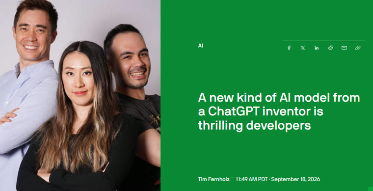

**Jev, from TypeSafe AI.** Early access. TypeSafe describes it as built "to make fast, structured decisions that software can use directly."

[TechCrunch, Sep 18, 2026](https://techcrunch.com/2026/09/18/a-new-kind-of-ai-model-from-a-chatgpt-inventor-is-thrilling-developers/) · [TypeSafe announcement](https://typesafe.ai/blog/introducing-system-one-models-and-jev) · [docs](https://docs.typesafe.ai/concepts/system-one)

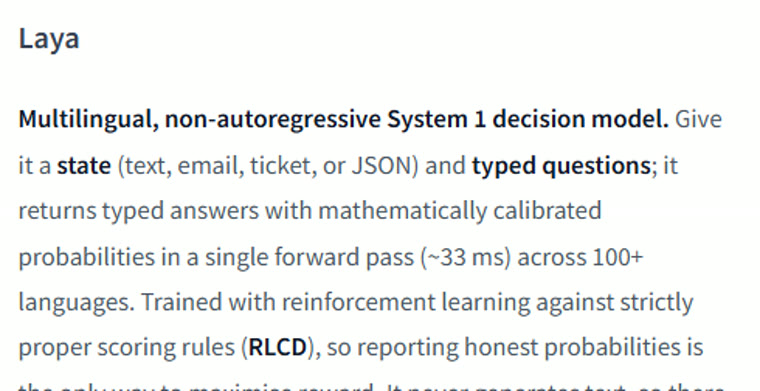

**Laya, from Convai Innovations.** Open weights under Apache 2.0. Takes text and typed questions and returns typed answers with probabilities.

[Hugging Face model card, posted Sep 18, 2026](https://huggingface.co/convaiinnovations/laya)

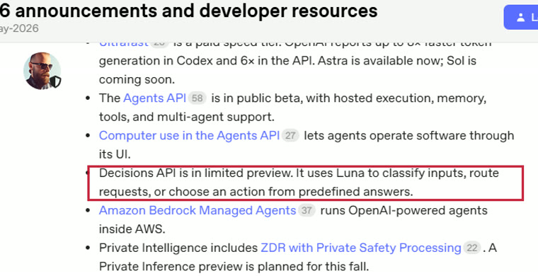

**Decisions API, from OpenAI.** In limited preview. It classifies inputs, routes requests, or chooses an action from answers the developer defines.

[OpenAI Developer Community, Sep 29, 2026](https://community.openai.com/t/devday-2026-announcements-and-developer-resources/1402006) · [DevDay recap](https://openai.com/index/devday-2026-recap/)

| | Structured extraction (today) | Decision models |
|---|---|---|
| Question | "What is the prerequisite?" | "Is this a graduate course: yes or no?" |
| Answer | Any text or number found in the source | One option from a list we wrote, or a score |
| Also returned | Nothing else | A probability for the answer |

# An App for Trying Schemas

[interactive chart not shown]

Open it in its own tab: huggingface.co/spaces/fmegahed/structured_text_extraction. The app is written in R with Shiny and ellmer.

# Demo 1: The ISA Catalog with an LLM

**Question.** Build the same data frame of ISA courses as in Class 10, with three more columns: the course code, the credit hours as a number, and the prerequisites on their own.

Step 1: one course

Open the vignette, copy its first example, and make it work on the text of ISA 125 with `chat$chat_structured()`.

Step 2: all 50 courses

One selector, `div.courseblock`, returns each course as a single block of text. Send every block with the same schema using `ellmer::parallel_chat_structured()`.

Page: bulletin.miamioh.edu/courses-instruction/isa/. We write the code together. Type it in `class12.Rmd`.

**Result.** One row per course. The model was `gpt-5-mini-2025-08-07`, run on Oct 05, 2026.

```
Rows: 50
Columns: 5
$ code         <chr> "ISA 125", "ISA 177", "ISA 211", "ISA 225", "ISA 235", "ISA 241…
$ name         <chr> "Introduction to Business Statistics", "Independent Studies", "…
$ credit_hours <int> 3, NA, 3, 3, 3, NA, NA, 3, NA, 3, 3, 3, 3, 3, 3, 3, NA, 3, 3, N…
$ course_desc  <chr> "This course provides an introduction to data, probability, sam…
$ prereqs      <chr> "MTH 102 or MTH 121 or MTH 125, MTH 122, MTH 141 or MTH 151; AC…
```

**Cost.** `include_tokens = TRUE` and `include_cost = TRUE` add these columns to the result.

Courses

50

Tokens sent / received

11,211 / 22,523

Total cost

$0.048

Time

30 seconds

The Class 10 version of this scrape used two selectors, made one request, and cost nothing. Here every course is its own request to a paid API, sent ten at a time.

**Checks.** Three ways to test the result without reading all 50 rows.

Is the text copied or reworded?

Of 47 descriptions returned, **30** are word-for-word copies of one passage on the page. Of the other **17**, 3 join sentences that are all on the page, and **14** contain wording that is not on the page.  
ISA 177 has no description on the page. One run returned "Variable credit (0-6 per term; maximum total 10)." and the other returned NA.

Does a second run agree?

The same code, run twice. Rows that differ, out of 50:  
code **0**, name **2**, credit_hours **1**, prereqs **12**, course_desc **20**.  
Many differences are small, such as a period at the end.

Does the type fit the data?

41 titles show a single credit number. The model's integer matches the title in **37**.  
ISA 241, ISA 242, ISA 628, ISA 629 are 1.5 credits. We asked for an integer, and the model returned NA for them. The other 9 titles show a range such as (0-6).

**Which of the five columns would you trust without checking?** Which would you check, and how?

**How would you change the schema** so that a 1.5 credit course and a (0-6) course both come back with useful values?

**For which of these columns is one line of string code the better tool?**

# Demo 2: A Chart Image to a Data Frame

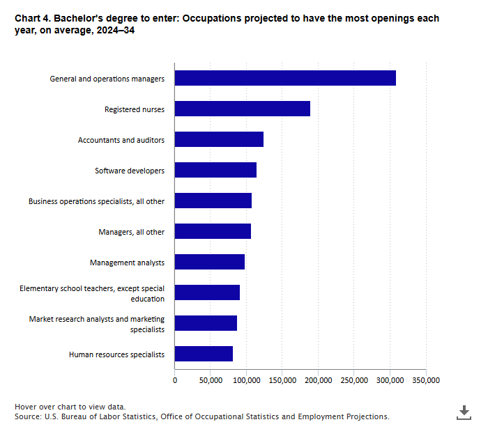

**Question.** This chart is a picture: there is no table and no tag to select. Build a data frame with one row per occupation and its projected openings each year.

Send the image with `ellmer::content_image_file()`. For many rows with the same columns, the schema is `ellmer::type_array()` around `ellmer::type_object()`.

Download [**bls_bachelors_openings.png** from Canvas](https://miamioh.instructure.com/courses/258169/files/40605451?module_item_id=6988251) and save it in your `data` folder.

Chart 4 in [Education level and projected openings, 2024-34](https://www.bls.gov/careeroutlook/2025/article/education-level-and-openings-2024-34.htm), U.S. Bureau of Labor Statistics, Career Outlook, September 2025.

**Result.** The model's values next to the numbers BLS publishes under the chart's "View Chart Data" link. Run on Oct 05, 2026.

| Occupation | Read from the image | Published by BLS | Difference |
| --- | --- | --- | --- |
| General and operations managers | 302,000 | 308,700 | -2.2% |
| Registered nurses | 186,000 | 189,100 | -1.6% |
| Accountants and auditors | 121,000 | 124,200 | -2.6% |
| Software developers | 110,000 | 115,200 | -4.5% |
| Business operations specialists, all other | 103,000 | 108,200 | -4.8% |
| Managers, all other | 99,000 | 106,700 | -7.2% |
| Management analysts | 92,000 | 98,100 | -6.2% |
| Elementary school teachers, except special education | 86,000 | 91,000 | -5.5% |
| Market research analysts and marketing specialists | 82,000 | 87,200 | -6.0% |
| Human resources specialists | 73,000 | 81,800 | -10.8% |

**All ten occupation names are correct.** The names are printed on the chart as text.

**None of the ten numbers is exact.** The chart prints no numbers, so the model estimated each one from the length of its bar. 10 of 10 estimates are below the published value, and the largest difference is 10.8%.

**The page has a "View Chart Data" table.** Which tool from Class 10 reads that table exactly? When would you still need the image?

# Choosing a Method

| The data is... | Use | Same result every run? | Cost | What to check |
|---|---|---|---|---|
| offered through an API | `httr2` (Classes 08, 09) | Yes | Free or a key | Status code, number of rows |
| in HTML, each value in its own tag | `rvest` and a CSS selector (Classes 10, 11) | Yes | Free | Element counts match the page |
| in text that follows a fixed pattern | String functions and regular expressions | Yes | Free | Rows where the pattern did not match |
| in free text, an image, or a PDF | An LLM with a schema (today) | No | Paid per token | A sample of rows against the source |

**From today's catalog run.** 50 courses cost $0.048 and took 30 seconds. 14 of 47 descriptions contain wording that is not on the page, and a second run changed the prerequisites text in 12 rows. Use the model for the columns that need it, and a selector or string code for the rest.

# Recap

# Summary of Main Points

By now, you should be able to do the following:

- **Explain** the role of LLMs in extraction: they return values that sit inside free text or an image, where no field name or tag points to them.
- **Use** an LLM API from R: `ellmer::chat_openai()`, then `chat$chat_structured()` for one text and `ellmer::parallel_chat_structured()` for many.
- **Write** a schema: `ellmer::type_object()` with one typed field per column, a description for each field, and `required = FALSE` for values that may be absent.
- **Compare** methods: selectors and string patterns are free and give the same result every run; an LLM handles free text and images, costs money, and needs its output checked against the source.

**Next class (Wed, Oct 7):** Tidy, technically correct, and consistent data.

# 🎯 Exam 01 and Assignments 🎯

Exam 01: Monday, Oct 12

Data acquisition and transformation (Phase I on the course schedule).  
**Practice exam:** the [**Fall 2025 Exam 01**](https://miamioh.instructure.com/courses/258169/quizzes/827524) is open on Canvas. Work through it with your notes and R open, the way you will take the exam.

**Before you leave:** knit, then commit and push `markdowns/class12.Rmd` and `class12.html`. If it is not pushed, it is not done.

Assignment 07: FSB Directory

One question, 10 points. Scrape the faculty and staff directory pages of the seven Farmer School departments into a single data frame: department, name, position, and website.  
Instructions and the due date are on the [**Canvas Assignments page**](https://miamioh.instructure.com/courses/258169/assignments).

**Reading, if you want more:** the ellmer articles on [structured data](https://ellmer.tidyverse.org/articles/structured-data.html) and [prompt design](https://ellmer.tidyverse.org/articles/prompt-design.html).